# Relationship Between Motor Capacity of the Contralesional and Ipsilesional Hand Depends on the Side of Stroke

### Rini Varghese and Carolee J. Winstein

- **Abstract**
- **Step 0: Loading Data & Packages**
- **Step 1: Descriptive Statistics**
- **Step 2: Pre-Checks for Inferential Statistics**
- **Step 3: Simple and Multiple Linear Regression**
  - Step 3a: Relationship between CL impairment and CL performance
  - Step 3b: Relationship between CL impairment and IL performance
  - Step 3c: Relationship between CL performance and IL performance

```r
library(IRdisplay)
display_html(
'<script>
code_show=true;
function code_toggle() {
  if (code_show){
    $(\'div.input\').hide();
  } else {
    $(\'div.input\').show();
  }
  code_show = !code_show
}
$( document ).ready(code_toggle);
</script>
  <form action="javascript:code_toggle()">
    <input type="submit" value="Click here to toggle on/off the raw code.">
 </form>'
)
```

## Abstract

**pdf:** 2

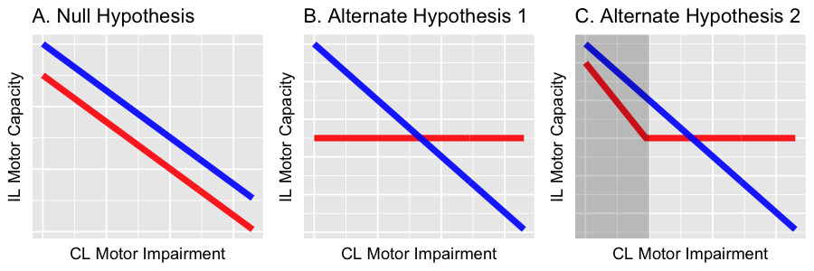

```r
x = rep(0:66,2)
y1 = c(rev(seq(from = 30, to = 50, length.out=20)),rep(30,47))
y2 = rev(seq(from = 0.75, to = 50, length.out=67))
y3 = rev(rep(25,67))
d = data.frame(x,y1,y2,y3)
library(ggplot2)

gg1 = ggplot(d, aes(x = x,y=y2)) +
  geom_line(alpha=0.9,size=2,col="red") +
  geom_line(aes(y=y2+10),alpha=0.9,size=2,col="blue") +
  xlab("CL Motor Impairment") + ylab("IL Motor Capacity") + ggtitle("A. Null Hypothesis") +
  #theme_bw() + theme(panel.grid = element_blank())+
        theme(axis.text.x=element_blank(),axis.text.y=element_blank(),
        axis.ticks.x=element_blank(),axis.ticks.y=element_blank())

gg2 = ggplot(d, aes(x = x,y=y1)) +
  geom_line(alpha=0.9,size=2,col="red") +
  geom_line(aes(y=y2+5),alpha=0.9,size=2,col="blue") +
  xlab("CL Motor Impairment") + ylab("IL Motor Capacity") + ggtitle("C. Alternate Hypothesis 2") +
        annotate("rect",xmin=-Inf, xmax=20, ymin=-Inf, ymax=Inf, alpha=0.2,fill="black") +
        theme(axis.text.x=element_blank(),axis.text.y=element_blank(),
        axis.ticks.x=element_blank(),axis.ticks.y=element_blank())

gg3 = ggplot(d, aes(x = x,y=y3)) +
  geom_line(alpha=0.9,size=2,col="red") +
  geom_line(aes(y=y2),alpha=0.9,size=2,col="blue") +
  xlab("CL Motor Impairment") + ylab("IL Motor Capacity") + ggtitle("B. Alternate Hypothesis 1") +
        theme(axis.text.x=element_blank(),axis.text.y=element_blank(),
        axis.ticks.x=element_blank(),axis.ticks.y=element_blank())

options(repr.plot.width=7.5, repr.plot.height=2.5)
source('~/Documents/My Documents/USC/Coursework/BKN 599 Stats in R/Data & Exercises/Data Packages/multiplot.R')
#If you want to print out below figure, uncomment the line of code below
#tiff("g0.tiff", units="in", width=7.5, height=2.5, res=1000); multiplot(gg1,gg3,gg2,cols=3); dev.off()
multiplot(gg1,gg3,gg2,cols=3)
```

## Step 0: Loading Data & Packages

```r
rm(list=ls())

ReqdLibs = c("repr","ggplot2","IRdisplay","psych","GGally",
             "huxtable","boot","broom","ggExtra")
suppressMessages(invisible(lapply(ReqdLibs, library, character.only = TRUE)))

wmft = read.csv("~/Documents/My Documents/USC/Lab/Projects/Aim 1_BM-AAUT_behavior/Aim 1b_BM_WMFT-CAHM/WMFT-AAUT analyses/wmftData_deID.csv")
suppressMessages(attach(wmft))
display_html('Data and necessary packages have been loaded.')
```

Data and necessary packages have been loaded.

```r
pr_dontshow = c(7,9)
display(wmft[,-pr_dontshow])
```

| subjNo | sex | sol | age | chron | uefm | IpDistAvg | CoDistAvg |
| --- | --- | --- | --- | --- | --- | --- | --- |
| 1 | male | LHD | 68.12 | 87.06 | 26 | 3.43750 | 106.01875 |
| 2 | male | LHD | 64.56 | 44.05 | 34 | 2.53125 | 6.34625 |
| 3 | male | LHD | 48.90 | 57.07 | 34 | 2.95125 | 30.73000 |
| 4 | male | LHD | 43.15 | 44.09 | 49 | 2.04125 | 3.05250 |
| 5 | male | LHD | 64.82 | 39.19 | 47 | 2.28875 | 4.34250 |
| 6 | male | LHD | 66.92 | 111.52 | 51 | 2.24875 | 3.40625 |
| 7 | male | LHD | 66.51 | 63.48 | 58 | 2.78500 | 3.89625 |
| 8 | female | LHD | 59.81 | 67.56 | 59 | 2.82500 | 3.91750 |
| 9 | male | LHD | 53.00 | 56.05 | 25 | 3.85750 | 35.83000 |
| 10 | female | LHD | 58.04 | 36.99 | 52 | 2.98375 | 30.96875 |
| 11 | male | LHD | 78.00 | 68.61 | 25 | 6.12875 | 107.19500 |
| 12 | male | LHD | 46.09 | 30.02 | 29 | 3.49125 | 64.63750 |
| 13 | male | LHD | 80.54 | 37.35 | 50 | 2.68250 | 3.05250 |
| 14 | male | LHD | 78.96 | 73.41 | 19 | 4.06125 | 63.67250 |
| 15 | female | LHD | 57.59 | 84.82 | 29 | 2.48625 | 17.28500 |
| 16 | male | LHD | 46.72 | 47.47 | 43 | 2.50375 | 20.58750 |
| 17 | female | LHD | 56.72 | 84.95 | 30 | 6.51000 | 97.77625 |
| 18 | male | LHD | 48.90 | 57.07 | 37 | 2.51125 | 12.38000 |
| 19 | female | LHD | 58.04 | 36.99 | 52 | 2.39000 | 9.38250 |
| 20 | male | LHD | 66.92 | 111.52 | 51 | 2.37625 | 3.42375 |
| 21 | female | LHD | 62.59 | 90.48 | 54 | 2.04625 | 4.23125 |
| 22 | male | RHD | 50.10 | 52.31 | 28 | 2.78375 | 84.11750 |
| 23 | female | RHD | 35.48 | 57.17 | 30 | 4.36250 | 25.32750 |
| 24 | female | RHD | 47.64 | 60.49 | 38 | 3.89750 | 16.64625 |
| 25 | male | RHD | 51.00 | 74.70 | 44 | 2.87625 | 5.95875 |
| 26 | male | RHD | 48.59 | 33.27 | 47 | 3.08625 | 10.06625 |
| 27 | female | RHD | 50.47 | 66.21 | 51 | 3.45250 | 5.36625 |
| 28 | male | RHD | 77.28 | 77.98 | 54 | 4.08625 | 5.77000 |
| 29 | female | RHD | 39.09 | 46.22 | 55 | 2.63500 | 24.31625 |
| 30 | male | RHD | 72.55 | 212.52 | 46 | 1.84000 | 2.27750 |
| 31 | male | RHD | 75.94 | 88.54 | 47 | 2.85000 | 3.59750 |
| 32 | male | RHD | 45.20 | 43.66 | 33 | 3.68250 | 14.64750 |
| 33 | male | RHD | 63.55 | 39.29 | 36 | 3.22750 | 10.27875 |
| 34 | female | RHD | 61.04 | 38.53 | 35 | 2.63125 | 9.32375 |
| 35 | male | RHD | 36.06 | 65.88 | 37 | 2.53875 | 35.23125 |
| 36 | male | RHD | 51.10 | 126.51 | 44 | 4.11750 | 6.37750 |
| 37 | male | RHD | 73.44 | 144.49 | 39 | 2.43250 | 6.29500 |
| 38 | male | RHD | 63.55 | 39.29 | 36 | 2.52375 | 6.55250 |
| 39 | male | RHD | 73.44 | 144.49 | 39 | 2.48125 | 4.77500 |
| 40 | male | RHD | 50.47 | 66.21 | 51 | 2.95875 | 4.82125 |
| 41 | male | RHD | 72.67 | 79.50 | 47 | 2.14750 | 2.32750 |
| 42 | male | RHD | 71.34 | 26.33 | 55 | 3.06500 | 3.23250 |

## Step 1: Descriptive Statistics

### Summarizing All Variables

**Full Sample**

```r
j = c(1,7,9)
as_hux(summary(wmft[,-j]),add_rownames = FALSE,add_colnames = FALSE)
```

|  | sex | sol | age | chron | uefm | IpDistAvg | CoDistAvg |
| --- | --- | --- | --- | --- | --- | --- | --- |
| X | female:11 | LHD:21 | Min. :35.48 | Min. : 26.33 | Min. :19.00 | Min. :1.840 | Min. : 2.277 |
| X.1 | male :31 | RHD:21 | 1st Qu.:49.20 | 1st Qu.: 43.76 | 1st Qu.:34.00 | 1st Qu.:2.491 | 1st Qu.: 4.259 |
| X.2 | NA | NA | Median :58.92 | Median : 61.98 | Median :43.50 | Median :2.805 | Median : 7.938 |
| X.3 | NA | NA | Mean :59.16 | Mean : 69.37 | Mean :41.57 | Mean :3.067 | Mean : 21.891 |
| X.4 | NA | NA | 3rd Qu.:67.82 | 3rd Qu.: 83.49 | 3rd Qu.:51.00 | 3rd Qu.:3.449 | 3rd Qu.: 25.075 |
| X.5 | NA | NA | Max. :80.54 | Max. :212.52 | Max. :59.00 | Max. :6.510 | Max. :107.195 |

#### Summary by Group (i.e., Side of Stroke Lesion)

- *Left Hemisphere Damage (LHD)*

```r
Lgrp = subset(wmft,sol=="LHD")
sl = summary(Lgrp[,-j])
as_hux(sl,add_rownames = FALSE,add_colnames = FALSE)
```

|  | sex | sol | age | chron | uefm | IpDistAvg | CoDistAvg |
| --- | --- | --- | --- | --- | --- | --- | --- |
| X | female: 6 | LHD:21 | Min. :43.15 | Min. : 30.02 | Min. :19.00 | Min. :2.041 | Min. : 3.053 |
| X.1 | male :15 | RHD: 0 | 1st Qu.:53.00 | 1st Qu.: 44.05 | 1st Qu.:29.00 | 1st Qu.:2.390 | 1st Qu.: 3.917 |
| X.2 | NA | NA | Median :59.81 | Median : 57.07 | Median :43.00 | Median :2.683 | Median : 12.380 |
| X.3 | NA | NA | Mean :60.71 | Mean : 63.32 | Mean :40.67 | Mean :3.102 | Mean : 30.102 |
| X.4 | NA | NA | 3rd Qu.:66.92 | 3rd Qu.: 84.82 | 3rd Qu.:51.00 | 3rd Qu.:3.438 | 3rd Qu.: 35.830 |
| X.5 | NA | NA | Max. :80.54 | Max. :111.52 | Max. :59.00 | Max. :6.510 | Max. :107.195 |

- *Right Hemisphere Damage (RHD)*

```r
Rgrp = subset(wmft,sol=="RHD")
sr = summary(Rgrp[,-j])
as_hux(sr,add_rownames = FALSE,add_colnames = FALSE)
```

|  | sex | sol | age | chron | uefm | IpDistAvg | CoDistAvg |
| --- | --- | --- | --- | --- | --- | --- | --- |
| X | female: 5 | LHD: 0 | Min. :35.48 | Min. : 26.33 | Min. :28.00 | Min. :1.840 | Min. : 2.277 |
| X.1 | male :16 | RHD:21 | 1st Qu.:48.59 | 1st Qu.: 43.66 | 1st Qu.:36.00 | 1st Qu.:2.539 | 1st Qu.: 4.821 |
| X.2 | NA | NA | Median :51.10 | Median : 65.88 | Median :44.00 | Median :2.876 | Median : 6.378 |
| X.3 | NA | NA | Mean :57.62 | Mean : 75.41 | Mean :42.48 | Mean :3.032 | Mean :13.681 |
| X.4 | NA | NA | 3rd Qu.:72.55 | 3rd Qu.: 79.50 | 3rd Qu.:47.00 | 3rd Qu.:3.453 | 3rd Qu.:14.648 |
| X.5 | NA | NA | Max. :77.28 | Max. :212.52 | Max. :55.00 | Max. :4.362 | Max. :84.118 |

- *Visualizing Group-Wise Independent Variables*

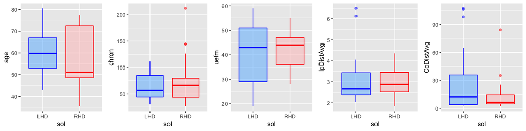

```r
g1 = ggplot(aes(y = age, x = sol,col=sol,fill=sol), data = wmft) +
    geom_boxplot(alpha=0.5,show.legend = FALSE) +
    scale_color_manual(values = c("LHD" = "blue", "RHD" = "red")) +
    scale_fill_manual(values=c("steelblue1","rosybrown1"))
g2 = ggplot(aes(y = chron, x = sol,col=sol,fill=sol,alpha=0.5), data = wmft) +
    geom_boxplot(alpha=0.5,show.legend = FALSE) +
    scale_color_manual(values = c("LHD" = "blue", "RHD" = "red")) +
    scale_fill_manual(values=c("steelblue1","rosybrown1"))
g3 = ggplot(aes(y = uefm, x = sol,col=sol,fill=sol,alpha=0.5), data = wmft) +
    geom_boxplot(alpha=0.5,show.legend = FALSE) +
    scale_color_manual(values = c("LHD" = "blue", "RHD" = "red")) +
    scale_fill_manual(values=c("steelblue1","rosybrown1"))
g4 = ggplot(aes(y = IpDistAvg, x = sol,col=sol,fill=sol,alpha=0.5), data = wmft) +
    geom_boxplot(alpha=0.5,show.legend = FALSE) +
    scale_color_manual(values = c("LHD" = "blue", "RHD" = "red")) +
    scale_fill_manual(values=c("steelblue1","rosybrown1"))
g5 = ggplot(aes(y = CoDistAvg, x = sol,col=sol,fill=sol,alpha=0.5), data = wmft) +
    geom_boxplot(alpha=0.5,show.legend = FALSE) +
    scale_color_manual(values = c("LHD" = "blue", "RHD" = "red")) +
    scale_fill_manual(values=c("steelblue1","rosybrown1"))

options(repr.plot.width=12, repr.plot.height=3)
source('~/Documents/My Documents/USC/Coursework/BKN 599 Stats in R/Data & Exercises/Data Packages/multiplot.R')
multiplot(g1,g2,g3,g4,g5,cols=5)
```

```r
display_markdown('*Comparing ***UEFM*** between LHD and RHD*')
rev(tidy(t.test(uefm[sol=="LHD"],uefm[sol=="RHD"])))
display_markdown('*Comparing ***Age*** between LHD and RHD*')
rev(tidy(t.test(age[sol=="LHD"],age[sol=="RHD"])))
display_markdown('*Comparing ***Chronicity*** between LHD and RHD*')
rev(tidy(t.test(chron[sol=="LHD"],chron[sol=="RHD"])))
display_markdown('*Comparing ***Sex*** between LHD and RHD*')
rev(tidy(chisq.test(sex[sol=="LHD"],sex[sol=="RHD"],simulate.p.value = TRUE)))
```

*Comparing ***UEFM** between LHD and RHD

| alternative | method | conf.high | conf.low | parameter | p.value | statistic | estimate2 | estimate1 | estimate |
| --- | --- | --- | --- | --- | --- | --- | --- | --- | --- |
| two.sided | Welch Two Sample t-test | 4.832243 | -8.45129 | 34.40068 | 0.5835417 | -0.5534398 | 42.47619 | 40.66667 | -1.809524 |

*Comparing ***Age** between LHD and RHD

| alternative | method | conf.high | conf.low | parameter | p.value | statistic | estimate2 | estimate1 | estimate |
| --- | --- | --- | --- | --- | --- | --- | --- | --- | --- |
| two.sided | Welch Two Sample t-test | 10.83511 | -4.654159 | 37.75538 | 0.4241519 | 0.808001 | 57.61905 | 60.70952 | 3.090476 |

*Comparing ***Chronicity** between LHD and RHD

| alternative | method | conf.high | conf.low | parameter | p.value | statistic | estimate2 | estimate1 | estimate |
| --- | --- | --- | --- | --- | --- | --- | --- | --- | --- |
| two.sided | Welch Two Sample t-test | 11.14608 | -35.32132 | 30.38367 | 0.2966244 | -1.061955 | 75.40905 | 63.32143 | -12.08762 |

*Comparing ***Sex** between LHD and RHD

| method | parameter | p.value | statistic |
| --- | --- | --- | --- |
| Pearson's Chi-squared test with simulated p-value (based on 2000 replicates) | NA | 1 | 0.23625 |

### Interim Summary

On an average, the 42 stroke survivors who participated in this study had moderate level of motor impairment (UEFM = 41.6), were approximately 60 years of age, 5.75 years post-stroke, and were predominantly male (74%). Welch t-tests were used to compare age, chronicity, and Upper Extremity Fugl-Meyer (UEFM) scores between LHD and RHD, whereas Chi-square tests was used to compare the proportion of females and males between the two groups.  
**There were no significant differences between LHD and RHD in the level of impairment, age, chronicity or the number of males.**

## Step 2: Pre-Checks for Inferential Statistics

### Checking Normality of Continuous Predictor and Response Variables

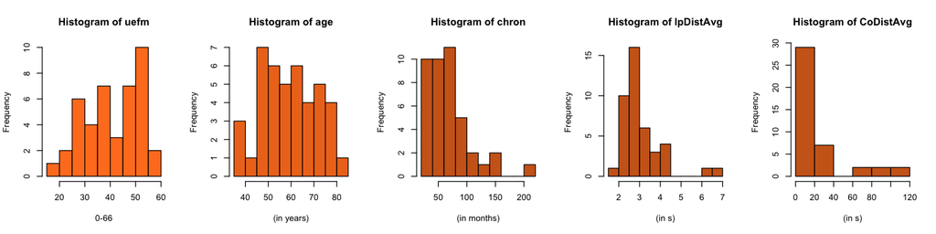

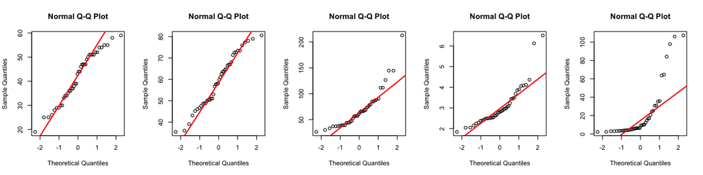

```r
options(repr.plot.width=12, repr.plot.height=3)
par(mfrow=c(1,5))
hist(uefm,xlab="0-66",col="chocolate1")
hist(age,xlab="(in years)",col="chocolate2")
hist(chron,xlab="(in months)",col="chocolate3")
hist(IpDistAvg,xlab="(in s)",col="chocolate3")
hist(CoDistAvg,xlab="(in s)",col="chocolate3")

qqnorm(uefm); qqline(uefm, col = "red", lwd = 2)
qqnorm(age); qqline(age, col = "red", lwd = 2)
qqnorm(chron); qqline(chron, col = "red", lwd = 2)
qqnorm(IpDistAvg); qqline(IpDistAvg, col = "red", lwd = 2)
qqnorm(CoDistAvg); qqline(CoDistAvg, col = "red", lwd = 2)
```

```r
zln.IpDistAvg = scale(log(IpDistAvg),scale = TRUE,center = TRUE)
zln.CoDistAvg = scale(log(CoDistAvg),scale = TRUE,center = TRUE)
zln.chron = scale(log(chron),scale = TRUE,center = TRUE)
z.uefm = scale(uefm,scale = TRUE,center = TRUE)
z.age = scale(age,scale = TRUE, center = TRUE)

wmft2 = data.frame(wmft, zln.chron, z.age, z.uefm, zln.IpDistAvg, zln.CoDistAvg)
```

### Transforming non-normal variables & Checking normality again

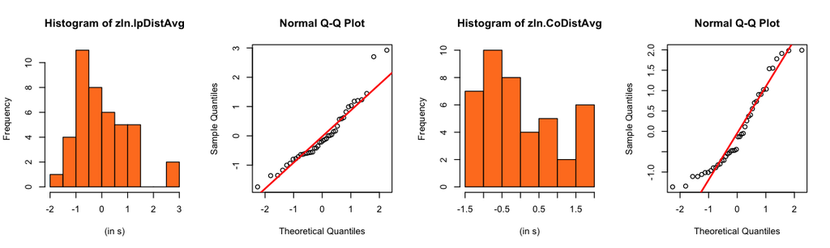

```r
options(repr.plot.width=10, repr.plot.height=3); par(mfrow=c(1,4))

hist(zln.IpDistAvg,xlab="(in s)",col="chocolate1")
qqnorm(zln.IpDistAvg); qqline(zln.IpDistAvg, col = "red", lwd = 2)
hist(zln.CoDistAvg,xlab="(in s)",col="chocolate1")
qqnorm(zln.CoDistAvg); qqline(zln.CoDistAvg, col = "red", lwd = 2)
```

### Checking Collinearity between Continuous Predictor Variables

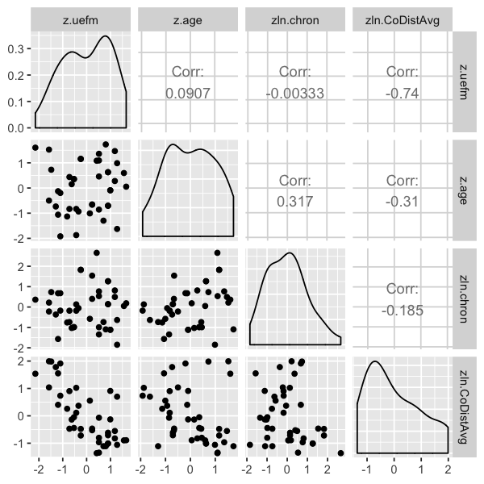

```r
options(repr.plot.width=5, repr.plot.height=5);
ggpairs(wmft2[, c("z.uefm", "z.age", "zln.chron","zln.CoDistAvg")])
```

**Age is significantly related to Chronicity**  
As we see below, age was significantly related to chronicity. This is not surprising, because chronicity is embeded in age, as a construct. That is, as people age with stroke they also become more chronic. So in fact, we do expect these to be related.

```r
r_un = cor.test(z.age,zln.chron)
tidy(r_un)
```

| estimate | statistic | p.value | parameter | conf.low | conf.high | method | alternative |
| --- | --- | --- | --- | --- | --- | --- | --- |
| 0.3167306 | 2.111911 | 0.040988 | 40 | 0.01416258 | 0.5661608 | Pearson's product-moment correlation | two.sided |

**Age is also significantly related to CL dexterous performance**  
As we see below, age is also significantly correlated with CL dexterous performance, which is expected as well. The fact that we are able to pick up age-related performance deficits using the dWMFT is pretty impressive. However, in the case of our model building, we must exercise caution. More on this is in the Interim Summary for this section.

```r
tidy(cor.test(z.age,zln.CoDistAvg))
```

| estimate | statistic | p.value | parameter | conf.low | conf.high | method | alternative |
| --- | --- | --- | --- | --- | --- | --- | --- |
| -0.3100719 | -2.062733 | 0.04567234 | 40 | -0.5611228 | -0.006779492 | Pearson's product-moment correlation | two.sided |

**As we would expect, CL impairment is significantly related to CL dexterous performance**  
This confirms that impairment and performance are related as we would expect.

```r
tidy(cor.test(z.uefm,zln.CoDistAvg))
```

| estimate | statistic | p.value | parameter | conf.low | conf.high | method | alternative |
| --- | --- | --- | --- | --- | --- | --- | --- |
| -0.7395393 | -6.948691 | 2.210886e-08 | 40 | -0.8519733 | -0.5619074 | Pearson's product-moment correlation | two.sided |

### Interim Summary

It is important to note that: age in the same model with either of these two would render one or all of the variables non-significant. Additionally, because UEFM and CoDistAvg were significantly correlated, the two cannot be included in the same model when evaluating their relationship with IpDistAvg. **This is not our intention or the purpose of our analyses, anyway, and is why we use two separate models.** That is, Model 1 with UEFM as the main predictor along with SOL, and Model 2 with CoDistAvg as the main predictor along with SOL.

## Step 3: Simple and Multiple Linear Models

## a) Relationship between CL impairment and CL dextrous performance

### Full Sample Simple Linear Model

**pdf:** 2

**Pearson's Correlation for the full sample**

| estimate | statistic | p.value | parameter | conf.low | conf.high | method | alternative |
| --- | --- | --- | --- | --- | --- | --- | --- |
| -0.7395393 | -6.948691 | 2.210886e-08 | 40 | -0.8519733 | -0.5619074 | Pearson's product-moment correlation | two.sided |

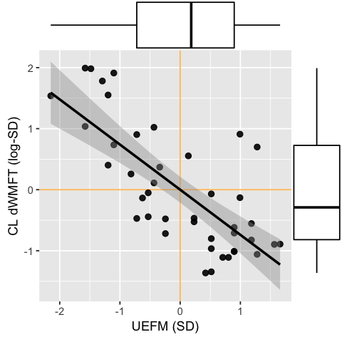

```r
options(repr.plot.width=4, repr.plot.height=4)

g1a = ggplot(wmft2, aes(x = z.uefm, y = zln.CoDistAvg)) +
  geom_hline(yintercept=0, color="orange", size=0.5,alpha=0.7) +
  geom_vline(xintercept=0, color="orange", size=0.5,alpha=0.7) +
  geom_point(alpha=0.9,size=2) +
  geom_smooth(method="lm",col="black",show.legend = FALSE) +
  xlab("UEFM (SD)") + ylab("CL dWMFT (log-SD)")
#If you want to print out below figure, uncomment the line of code below
#tiff("g1a.tiff", units="in", width=3, height=3, res=1000); g1a; dev.off()
ggMarginal(p = g1a, type = "boxplot")

display_markdown("<br>**Pearson's Correlation for the full sample**")
tidy(cor.test(z.uefm,zln.CoDistAvg))
```

### Group-Wise Simple Linear Models

**pdf:** 2

**Pearson's Correlation for the LHD group**

| estimate | statistic | p.value | parameter | conf.low | conf.high | method | alternative |
| --- | --- | --- | --- | --- | --- | --- | --- |
| -0.81719 | -6.18016 | 6.138222e-06 | 19 | -0.9231996 | -0.5956202 | Pearson's product-moment correlation | two.sided |

**Pearson's Correlation for the RHD group**

| estimate | statistic | p.value | parameter | conf.low | conf.high | method | alternative |
| --- | --- | --- | --- | --- | --- | --- | --- |
| -0.5770214 | -3.079574 | 0.006169532 | 19 | -0.8075528 | -0.1935453 | Pearson's product-moment correlation | two.sided |

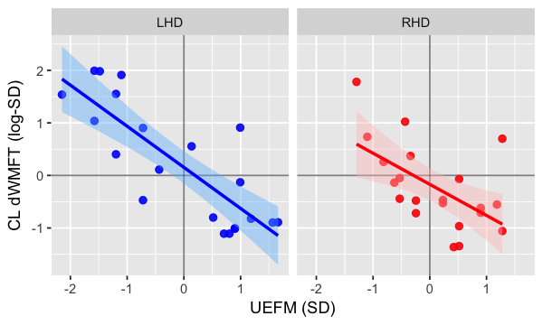

```r
options(repr.plot.width=5, repr.plot.height=3)

g1b = ggplot(wmft2, aes(x = z.uefm, y = zln.CoDistAvg)) +
  geom_hline(yintercept=0, color="black", size=0.5,alpha=0.5) +
  geom_vline(xintercept=0, color="black", size=0.5,alpha=0.5) +
  geom_point(aes(color=sol),alpha=0.9,size=2,show.legend = FALSE) +
  geom_smooth(aes(color=sol,fill=sol),method="lm",show.legend = FALSE) +
  scale_color_manual(values = c("LHD" = "blue", "RHD" = "red")) +
  scale_fill_manual(values = c('steelblue1','rosybrown1')) +
  facet_wrap(~sol)+ xlab("UEFM (SD)") + ylab("CL dWMFT (log-SD)")
#If you want to print out below figure, uncomment the line of code below
#tiff("g1b.tiff", units="in", width=5, height=3, res=1000); g1b; dev.off()
g1b
display_markdown("<br>**Pearson's Correlation for the LHD group**")
tidy(cor.test(z.uefm[sol=="LHD"],zln.CoDistAvg[sol=="LHD"]))
display_markdown("<br>**Pearson's Correlation for the RHD group**")
tidy(cor.test(z.uefm[sol=="RHD"],zln.CoDistAvg[sol=="RHD"]))
```

### Multiple Linear Model

**Model 0 Full:** $\;\;$ *CoDistAvg* $= β_{0} +\; β_{1}$ (*UEFM*) $ + \;β_{2}$ (*SoL*) $ + \;β_{3}$ (*UEFM x SoL*) $ + \; β_{4}$ (*Age*) $+ \; β_{5}$(*Sex*) $+\; β_{6}$(*Chronicity*)$ \;+ \;\epsilon $  
**Model 0 Reduced:** $\;\;$ *CoDistAvg* $= β_{0} +\; β_{1}$ (*UEFM*) $ \;+ \;β_{2}$ (*SoL*) $ + \;β_{3}$ (*UEFM x SoL*) $ + \;β_{4}$ (*Age*) $+ \; β_{5}$(*Sex*) $\; +\; \epsilon $  
**Hypotheses:**  
$\: \:$ $H_{0}: β_{1} = 0\;$  
$\: \:$ $ H_{1}: β_{1} ≠ 0\; $

**Comparing the Full and Reduced Models:**  
We begin with a full model in which we include age, sex, chronicity, uefm, and side of lesion (as well as our hypothesized interaction term), all as predictors. Then, we remove those predictors that don't satisfy the p = 0.2 lenient criteria. Below are logical outputs from the full model, for those coefficients which meet this liberal cut-off. That is, the predictors for which the value is TRUE are those that the p-value cut-off was met. These predictors were included in the final reduced model.

```r
# Full Model with all explanatory variables for backward selection
lm.fullMod1 = lm(zln.CoDistAvg ~ z.uefm*sol + z.age + sex + zln.chron, data = wmft2)
summary(lm.fullMod1)$coefficients[,4]<0.2

# Reduced model after taking out zln.chron which was not statistically significant
lm.redMod1 = lm(zln.CoDistAvg ~ z.uefm*sol + z.age + sex, data = wmft2)
huxreg('Full' = lm.fullMod1,'Reduced' = lm.redMod1)
```

**(Intercept)**

TRUE

**z.uefm**

TRUE

**solRHD**

TRUE

**z.age**

TRUE

**sexmale**

TRUE

**zln.chron**

FALSE

**z.uefm:solRHD**

TRUE

| names | Full | Reduced |
| --- | --- | --- |
|  | Full | Reduced |
| (Intercept) | 0.45755737891864 * | 0.468396441663592 * |
|  | (0.201329185753794) | (0.200815885448626) |
| z.uefm | -0.83680129182798 *** | -0.831796233240791 *** |
|  | (0.113293139797745) | (0.113062054998122) |
| solRHD | -0.341365719311831 | -0.371449561641543 |
|  | (0.189249278243945) | (0.186472367421827) |
| z.age | -0.21415105624646 | -0.247454752328396 * |
|  | (0.10596178281468) | (0.100069363221867) |
| sexmale | -0.409124023983039 | -0.403435242340342 |
|  | (0.222622253074398) | (0.222323768383166) |
| zln.chron | -0.0953070806473189 |  |
|  | (0.0988932426998097) |  |
| z.uefm:solRHD | 0.350588336729632 | 0.35068112225223 |
|  | (0.207738357858294) | (0.207532772191029) |
| N | 42 | 42 |
| R2 | 0.700806787540939 | 0.692867147906934 |
| logLik | -33.749389717253 | -34.2993972888685 |
| AIC | 83.498779434506 | 82.5987945777371 |
| *** p < 0.001; ** p < 0.01; * p < 0.05. |  |  |

#### Estimates from the Final Reduced Model & Model Diagnostics

| term | estimate | std.error | statistic | p.value | conf.low | conf.high |
| --- | --- | --- | --- | --- | --- | --- |
| (Intercept) | 0.4683964 | 0.2008159 | 2.332467 | 2.538400e-02 | 0.06112295 | 0.875669934 |
| z.uefm | -0.8317962 | 0.1130621 | -7.356988 | 1.123030e-08 | -1.06109671 | -0.602495758 |
| solRHD | -0.3714496 | 0.1864724 | -1.991982 | 5.399989e-02 | -0.74963305 | 0.006733928 |
| z.age | -0.2474548 | 0.1000694 | -2.472832 | 1.826126e-02 | -0.45040483 | -0.044504677 |
| sexmale | -0.4034352 | 0.2223238 | -1.814629 | 7.792088e-02 | -0.85432874 | 0.047458259 |
| z.uefm:solRHD | 0.3506811 | 0.2075328 | 1.689763 | 9.971685e-02 | -0.07021485 | 0.771577093 |

| r.squared | adj.r.squared | sigma | statistic | p.value | df | logLik | AIC | BIC | deviance | df.residual |
| --- | --- | --- | --- | --- | --- | --- | --- | --- | --- | --- |
| 0.6928671 | 0.6502098 | 0.5914306 | 16.24262 | 2.243188e-08 | 6 | -34.2994 | 82.59879 | 94.76248 | 12.59245 | 36 |

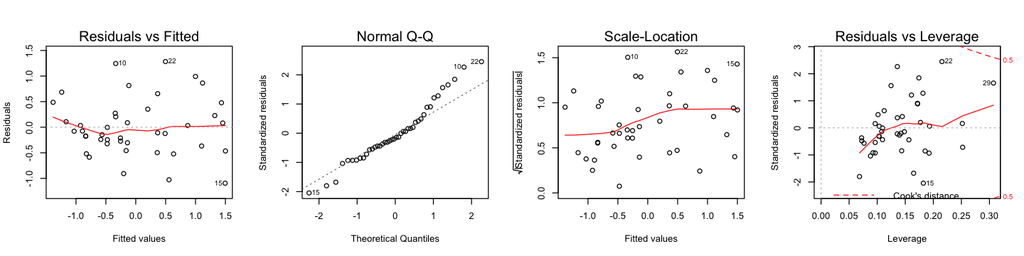

```r
# Display reduced model estimates, diagnostics and plot model fit
tidy(lm.redMod1,conf.int = TRUE); glance(lm.redMod1)
options(repr.plot.width=12, repr.plot.height=3); par(mfrow=c(1,4))
plot(lm.redMod1);
```

## b) Relationship between CL impairment and IL dextrous performance

### Full Sample Simple Linear Model

**pdf:** 2

**Pearson's Correlation for the full sample**

| estimate | statistic | p.value | parameter | conf.low | conf.high | method | alternative |
| --- | --- | --- | --- | --- | --- | --- | --- |
| -0.4612207 | -3.287573 | 0.002110765 | 40 | -0.6710804 | -0.1829327 | Pearson's product-moment correlation | two.sided |

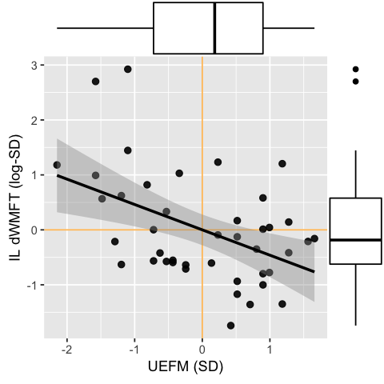

```r
options(repr.plot.width=4, repr.plot.height=4)

g2a = ggplot(wmft2, aes(x = z.uefm, y = zln.IpDistAvg)) +
  geom_hline(yintercept=0, color="orange", size=0.5,alpha=0.7) +
  geom_vline(xintercept=0, color="orange", size=0.5,alpha=0.7) +
  geom_point(alpha=0.9,size=2) +
  geom_smooth(method="lm",se = TRUE,col="black",show.legend = FALSE) +
  xlab("UEFM (SD)") + ylab("IL dWMFT (log-SD)")

#If you want to print out below figure, uncomment the line of code below
#tiff("g2a.tiff", units="in", width=3, height=3, res=1000); g2a; dev.off()

ggMarginal(p = g2a, type = "boxplot")
display_markdown("<br>**Pearson's Correlation for the full sample**")
tidy(cor.test(z.uefm,zln.IpDistAvg))
```

### Group-Wise Simple Linear Models

**Pearson's Correlation for the LHD group**

| estimate | statistic | p.value | parameter | conf.low | conf.high | method | alternative |
| --- | --- | --- | --- | --- | --- | --- | --- |
| -0.6484748 | -3.713218 | 0.001474631 | 19 | -0.8439171 | -0.3010685 | Pearson's product-moment correlation | two.sided |

**Pearson's Correlation for the RHD group**

| estimate | statistic | p.value | parameter | conf.low | conf.high | method | alternative |
| --- | --- | --- | --- | --- | --- | --- | --- |
| -0.06576191 | -0.2872714 | 0.7770142 | 19 | -0.4837167 | 0.3766165 | Pearson's product-moment correlation | two.sided |

```
<environment: R_GlobalEnv>
```

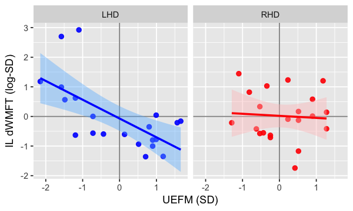

```r
options(repr.plot.width=5, repr.plot.height=3)

g2b = ggplot(wmft2, aes(x = z.uefm, y = zln.IpDistAvg)) +
  geom_hline(yintercept=0, color="black", size=0.5,alpha=0.5) +
  geom_vline(xintercept=0, color="black", size=0.5,alpha=0.5) +
  geom_point(aes(color=sol),alpha=0.9,size=2,show.legend = FALSE) +
  geom_smooth(aes(color=sol,fill=sol),method="lm",show.legend = FALSE) +
  scale_color_manual(values = c("LHD" = "blue", "RHD" = "red")) +
  scale_fill_manual(values = c('steelblue1','rosybrown1')) + theme(legend.title=element_blank()) +
  facet_wrap(~sol)+ xlab("UEFM (SD)") + ylab("IL dWMFT (log-SD)")


#If you want to print out below figure, uncomment the line of code below
#tiff("g2b.tiff", units="in", width=5, height=3, res=1000); g2b; dev.off()

g2b
display_markdown("<br>**Pearson's Correlation for the LHD group**")
tidy(cor.test(z.uefm[sol=="LHD"],zln.IpDistAvg[sol=="LHD"]))
display_markdown("**<br>Pearson's Correlation for the RHD group**")
tidy(cor.test(z.uefm[sol=="RHD"],zln.IpDistAvg[sol=="RHD"]))

#tiff("g2.tiff", units="in", width=7.5, height=2.5, res=1000); multiplot(g2a,g2b[[1]],cols=2); dev.off()
```

### Thorndike Type-2 Corrections

Next, we use Thordike type 2 corrections to correct for range restrictions in UEFM measure of RHD. We use the entire sample's variance (i.e., standard deviation) to specify the unrestricted range.

## $ R = \frac {r\frac{S}{s}} {\sqrt {1-r^2 \;+\; r^2(\frac {S^2}{s^2})}} $

$r_{s}$ = observed correlation between CL UEFM and IL dWMFT in the restricted sample  
$s$ = estimated SD of CL UEFM in the RHD  
$S$ = estimated SD of CL UEFM in the full sample  
$R$ = estimated corrected correlation in the unrestricted sample when only the restricted sample has been used

```r
tdike_r = rangeCorrection(cor(z.uefm[sol=="RHD"],zln.IpDistAvg[sol=="RHD"]),
                          sd(uefm[sol=="RHD"]),sd(uefm))
display_markdown(paste("We find that the Thorndike-corrected correlation for RHD is:",round(tdike_r,digits = 3)))
```

We find that the Thorndike-corrected correlation for RHD is: -0.051

### Multiple Linear Model

**Model 1 Full:** $\;\;$ *IpDistAvg* $= β_{0} +\; β_{1}$ (*UEFM*) $ + \;β_{2}$ (*SoL*) $ + \;β_{3}$ (*UEFM x SoL*) $ + \; β_{4}$ (*Age*) $+ \; β_{5}$(*Sex*) $+\; β_{6}$(*Chronicity*)$ \;+ \;\epsilon $  
**Model 1 Reduced:** $\;\;$ *IpDistAvg* $= β_{0} +\; β_{1}$ (*UEFM*) $ + \;β_{2}$ (*SoL*) $ + \;β_{3}$ (*UEFM x SoL*) $ + \; β_{4}$(*Sex*) $\; +\;\epsilon $  
**Hypotheses:**  
$\: \:$ $H_{0}: β_{1} = 0\;$ & $\;β_{3} = 0.$  
$\: \:$ $ H_{1}: β_{1} ≠ 0\;$ & $ \;β_{3} ≠ 0. $  
*Note*: $\;β_{3}$ is the interaction effect that we seek to test. This is the main hypothesis of this paper.

**Comparing the Full and Reduced Models:**  
We begin with a full model in which we include age, sex, chronicity, uefm, and side of lesion (as well as our hypothesized interaction term), all as predictors. Then, we remove those predictors that don't satisfy the p = 0.2 lenient criteria. Below are logical outputs from the full model, for those coefficients which meet this liberal cut-off. That is, the predictors for which the value is TRUE are those that the p-value cut-off was met. These predictors were included in the final reduced model.

```r
# Full Model with all explanatory variables for backward selection
lm.fullMod2 = lm(zln.IpDistAvg ~ z.uefm*sol + sex + z.age + zln.chron, data = wmft2)
summary(lm.fullMod2)$coefficients[,4]<0.2

# Reduced model after taking out zln.chron which was not statistically significant
lm.redMod2 = lm(zln.IpDistAvg ~ z.uefm*sol + sex, data = wmft2)
huxreg('Full' = lm.fullMod2,'Reduced' = lm.redMod2)
```

**(Intercept)**

FALSE

**z.uefm**

TRUE

**solRHD**

FALSE

**sexmale**

TRUE

**z.age**

FALSE

**zln.chron**

FALSE

**z.uefm:solRHD**

TRUE

| names | Full | Reduced |
| --- | --- | --- |
|  | Full | Reduced |
| (Intercept) | 0.30234323104036 | 0.311852001675021 |
|  | (0.297468274461092) | (0.286704052872401) |
| z.uefm | -0.697918929154608 *** | -0.692137395329895 *** |
|  | (0.167393091457328) | (0.163698999812027) |
| solRHD | 0.154264188901328 | 0.119119893176487 |
|  | (0.279619946961279) | (0.266196706847092) |
| sexmale | -0.551131845714574 | -0.540352307926362 |
|  | (0.3289292470475) | (0.307594404921321) |
| z.age | 0.0433641840661717 |  |
|  | (0.156560851198444) |  |
| zln.chron | -0.104368517725902 |  |
|  | (0.146116928609393) |  |
| z.uefm:solRHD | 0.634219625431472 * | 0.636705461079813 * |
|  | (0.306937966396274) | (0.296493744539126) |
| N | 42 | 42 |
| R2 | 0.346840013942241 | 0.337278369490749 |
| logLik | -50.144773071465 | -50.4499647620087 |
| AIC | 116.28954614293 | 112.899929524017 |
| *** p < 0.001; ** p < 0.01; * p < 0.05. |  |  |

#### Estimates from the Final Reduced Model & Model Diagnostics

| term | estimate | std.error | statistic | p.value | conf.low | conf.high |
| --- | --- | --- | --- | --- | --- | --- |
| (Intercept) | 0.3118520 | 0.2867041 | 1.0877140 | 0.2837563295 | -0.26906559 | 0.89276959 |
| z.uefm | -0.6921374 | 0.1636990 | -4.2281101 | 0.0001481802 | -1.02382307 | -0.36045172 |
| solRHD | 0.1191199 | 0.2661967 | 0.4474882 | 0.6571315422 | -0.42024587 | 0.65848565 |
| sexmale | -0.5403523 | 0.3075944 | -1.7567040 | 0.0872422741 | -1.16359777 | 0.08289316 |
| z.uefm:solRHD | 0.6367055 | 0.2964937 | 2.1474499 | 0.0383765645 | 0.03595207 | 1.23745885 |

| r.squared | adj.r.squared | sigma | statistic | p.value | df | logLik | AIC | BIC | deviance | df.residual |
| --- | --- | --- | --- | --- | --- | --- | --- | --- | --- | --- |
| 0.3372784 | 0.2656328 | 0.8569523 | 4.707595 | 0.0035838 | 5 | -50.44996 | 112.8999 | 123.3259 | 27.17159 | 37 |

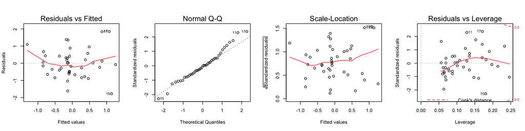

```r
# Display reduced model estimates, diagnostics and plot model fit
tidy(lm.redMod2,conf.int = TRUE); glance(lm.redMod2)
options(repr.plot.width=12, repr.plot.height=3); par(mfrow=c(1,4))
plot(lm.redMod2);
```

#### Bootstrapping SE and 95% CI of Coefficient Estimates from the Reduced Model

```r
bootFn.Mod2=function(data,index)
    return(coef(lm(zln.IpDistAvg ~ z.uefm*sol + sex, data = wmft2[index,])))

set.seed(1)
index = sample(42,42,replace=T)

b.Mod2 = boot(wmft2,bootFn.Mod2,1000)
tidy(b.Mod2,conf.int = TRUE)
```

| term | statistic | bias | std.error | conf.low | conf.high |
| --- | --- | --- | --- | --- | --- |
| (Intercept) | 0.3118520 | -0.017003493 | 0.3963488 | -0.46611066 | 1.0538934 |
| z.uefm | -0.6921374 | -0.010438456 | 0.2045903 | -1.13721935 | -0.3373701 |
| solRHD | 0.1191199 | 0.001373228 | 0.2563943 | -0.39834554 | 0.6147940 |
| sexmale | -0.5403523 | 0.004430638 | 0.3812708 | -1.29091859 | 0.2129279 |
| z.uefm:solRHD | 0.6367055 | 0.022418843 | 0.3124731 | 0.05529932 | 1.3061177 |

#### Plotting the Bootstrap Distribution of Estimate for the Interaction Term

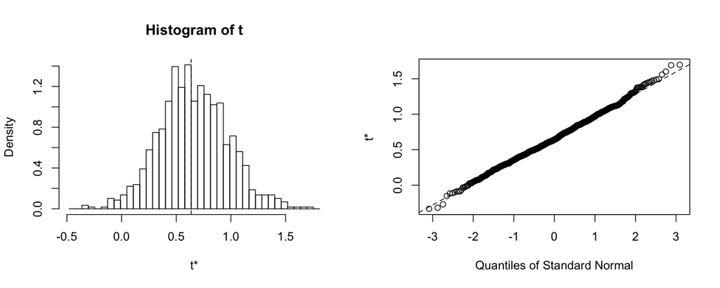

```r
options(repr.plot.width=10, repr.plot.height=4)
plot(b.Mod2,index=5)
```

### Interim Summary

The final reduced form of Model 1 was statistically different from a null model (F = 4.71, p = 0.003, adjusted $R^{2}=$ 0.26). Based on estimates from this model, CL impairment (UEFM) was significantly associated with IL hand motor performance, i.e., dWMFT, ($β_{1} =$ -0.69 ± 0.16, p < 0.001). There was no significant effect of the side of lesion ($β_2 =$ 0.12 ± 0.27, p = 0.66). **However, as hypothesized, we also found a significant interaction between the side of lesion and CL impairment ($β_3 =$ 0.64 ± 0.29, p = 0.038).**

## c) Relationship between CL dexterous performance and IL dextrous performance

### Full Sample Simple Linear Model

**pdf:** 2

**Pearson's Correlation for the full sample**

| estimate | statistic | p.value | parameter | conf.low | conf.high | method | alternative |
| --- | --- | --- | --- | --- | --- | --- | --- |
| 0.6199833 | 4.997507 | 1.193452e-05 | 40 | 0.3894339 | 0.777423 | Pearson's product-moment correlation | two.sided |

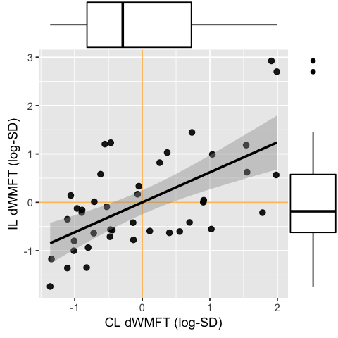

```r
options(repr.plot.width=4, repr.plot.height=4)

g3a = ggplot(wmft2, aes(x = zln.CoDistAvg, y = zln.IpDistAvg)) +
  geom_hline(yintercept=0, color="orange", size=0.5,alpha=0.7) +
  geom_vline(xintercept=0, color="orange", size=0.5,alpha=0.7) +
  geom_point(alpha=0.9,size=2) +
  geom_smooth(method="lm",col="black",show.legend = FALSE) +
  #theme_bw() + theme(panel.grid = element_blank())+
  xlab("CL dWMFT (log-SD)") + ylab("IL dWMFT (log-SD)")

#If you want to print out below figure, uncomment the line of code below
#tiff("g3a.tiff", units="in", width=3, height=3, res=1000); g3a; dev.off()

ggMarginal(p = g3a, type = "boxplot")

display_markdown("<br>**Pearson's Correlation for the full sample**")
tidy(cor.test(zln.CoDistAvg,zln.IpDistAvg))
```

### Group-Wise Simple Linear Models

**pdf:** 2

**Pearson's Correlation for the LHD group**

| estimate | statistic | p.value | parameter | conf.low | conf.high | method | alternative |
| --- | --- | --- | --- | --- | --- | --- | --- |
| 0.808814 | 5.995155 | 9.072077e-06 | 19 | 0.5794418 | 0.9194654 | Pearson's product-moment correlation | two.sided |

**Pearson's Correlation for the RHD group**

| estimate | statistic | p.value | parameter | conf.low | conf.high | method | alternative |
| --- | --- | --- | --- | --- | --- | --- | --- |
| 0.297153 | 1.356535 | 0.1908303 | 19 | -0.1543309 | 0.6459759 | Pearson's product-moment correlation | two.sided |

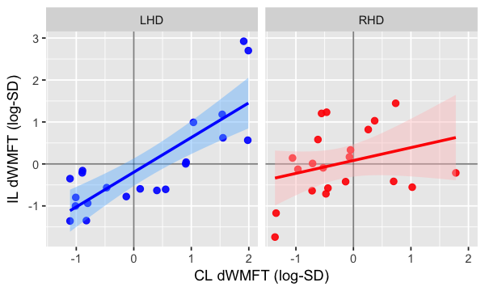

```r
options(repr.plot.width=5, repr.plot.height=3)

g3b = ggplot(wmft2, aes(x = zln.CoDistAvg, y = zln.IpDistAvg)) +
  geom_hline(yintercept=0, color="black", size=0.5,alpha=0.5) +
  geom_vline(xintercept=0, color="black", size=0.5,alpha=0.5) +
  geom_point(aes(color=sol),alpha=0.9,size=2,show.legend = FALSE) +
  geom_smooth(aes(color=sol,fill=sol),method="lm",show.legend = FALSE) +
  scale_color_manual(values = c("LHD" = "blue", "RHD" = "red")) +
  scale_fill_manual(values = c('steelblue1','rosybrown1')) + theme(legend.title=element_blank()) +
  #theme_bw() + theme(panel.grid = element_blank())+
  facet_wrap(~sol)+ xlab("CL dWMFT (log-SD)") + ylab("IL dWMFT (log-SD)")

#If you want to print out below figure, uncomment the line of code below
#tiff("g3b.tiff", units="in", width=5, height=3, res=1000); g3b; dev.off()

g3b
display_markdown("<br>**Pearson's Correlation for the LHD group**")
tidy(cor.test(zln.CoDistAvg[sol=="LHD"],zln.IpDistAvg[sol=="LHD"]))
display_markdown("<br>**Pearson's Correlation for the RHD group**")
tidy(cor.test(zln.CoDistAvg[sol=="RHD"],zln.IpDistAvg[sol=="RHD"]))

multiplot()
```

### Thorndike Type-2 Corrections

Next, we use Thordike type 2 corrections to correct for range restrictions in CoDistAvg measure of RHD. We use the entire sample's variance (i.e., standard deviation) to specify the unrestricted range.